# Replacement Class - Cleaning up and Spatial Joins

Coach Skufca

2022-11-09

This notebooks will help me talk through a bit of material regarding *spatial data*, with some introduction to `spatial joins`.

Key topics for today:

- Using `sf` package
- Using `tmap` package
- Using `tidycensus` package
- Reminder on joins (focus: left join)
- Our Spatial Data
  - Neighborhoods
  - Joining with non-spatial data
  - Census data
  - Joining with spatial data
- ignore html in git (if time)

## Packages

Standards:

```r
library(knitr)
library(tidyverse)
library(janitor)
library(lubridate) # because we will probably see some dates
library(here) # a package I haven't taught you about before that doesn't do much, but ....
```

Some additional packages focused on today’s work:

```r
library(sf) # working with simple features - geospatial
library(tmap)
library(tidycensus)
```

## Informational resources

- An overall resource on mapping in R: https://bookdown.org/nicohahn/making_maps_with_r5/docs/introduction.html
- A starting point to learn about `sf`: https://r-spatial.github.io/sf/articles/
- Getting started with `tmap`: https://cran.r-project.org/web/packages/tmap/vignettes/tmap-getstarted.html
- The `tidycensus` package: https://walker-data.com/tidycensus/index.html
- The book on `tidycensus` : https://walker-data.com/census-r/index.html

## Using the Neighborhood Geospatial Data (using /data)

Our first data source comes from opendata.dc

https://opendata.dc.gov/datasets/DCGIS::dc-health-planning-neighborhoods/about

I will use the GeoJSON file. (Newer, not necessarily better, but … a single file. Not smaller, but … this one is not big.)

Data is easily readable

```r
neigh=st_read(here("data_raw","dc_neigh.geojson")) %>% clean_names()
class(neigh)
```

```
[1] "sf"         "data.frame"
```

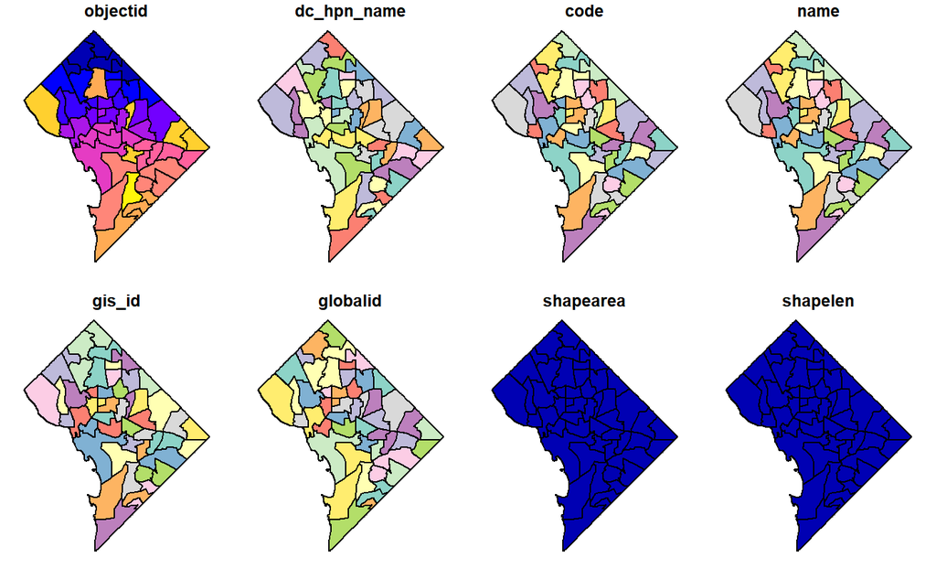

```r
plot(neigh)
```

## Reminder - Joins

```r
df1=tibble(fruit=c("apple","banana","cherry"),cost=c(1.5,1.2,2.25))
df2=tibble(fruit=c("apple","apple","cherry","lemon"),
           desert=c("pie","cobbler","cobbler","cheesecake"),
           cal=c(400,430,500,550))
df1
```

| fruit | cost |
| --- | --- |
| apple | 1.50 |
| banana | 1.20 |
| cherry | 2.25 |

```r
df2
```

| fruit | desert | cal |
| --- | --- | --- |
| apple | pie | 400 |
| apple | cobbler | 430 |
| cherry | cobbler | 500 |
| lemon | cheesecake | 550 |

```r
left_join(df1,df2,by="fruit")
```

| fruit | cost | desert | cal |
| --- | --- | --- | --- |
| apple | 1.50 | pie | 400 |
| apple | 1.50 | cobbler | 430 |
| banana | 1.20 | NA | NA |
| cherry | 2.25 | cobbler | 500 |

## Investigating joining spatial and non-spatial data

Covid case information is available from opendatadc:

https://opendata.dc.gov/datasets/DCGIS::dc-covid-19-total-positive-cases-by-neighborhood/about

Read cases information:

```r
df_c=read_csv(here("data_raw","neighborhood_cases.csv")) %>% clean_names()

df_cases=df_c %>%
  filter(as_date(date_reported) == "2022-02-22") %>%
  separate(neighborhood,into=c("code","name"),sep = ":") %>%
  mutate(code=case_when(
    code=="N35" ~"N0",
    TRUE ~ code
  )) %>%
  select(-objectid,-date_reported)
```

## Regular joining (of dataframes)

```r
neigh2=left_join(neigh,df_cases,by=c("code"))

tmap_mode("view")
```

```
tmap mode set to interactive viewing
```

```r
tm_shape(neigh2) +tm_polygons("total_positives",alpha=.5)
```

[interactive chart not shown]

## Joining with other spatial data

Let’s get some data using `tidycensus`. Need an API key https://api.census.gov/data/key_signup.html

```r
census_api_key("260b47c83abf4017c26b5022527d1558744b41cf", overwrite = TRUE)
```

```
To install your API key for use in future sessions, run this function with `install = TRUE`.
```

```r
#what variables
v20 = load_variables(2018,"acs5")
# median_family_income="    B06011_001"
# all "B00001_001"
#black "B02009_001"
```

Get some data:

```r
df_cencus=get_acs(geography = "tract",
                  variables=c("median_inc"="B06011_001",
                              "pop"="B01001_001",
                              "pop_black"="B02009_001"),
                  state="DC",geometry=TRUE,year=2018)
```

```
Downloading feature geometry from the Census website.  To cache shapefiles for use in future sessions, set `options(tigris_use_cache = TRUE)`.
```

```r
class(df_cencus)
```

```
[1] "sf"         "data.frame"
```

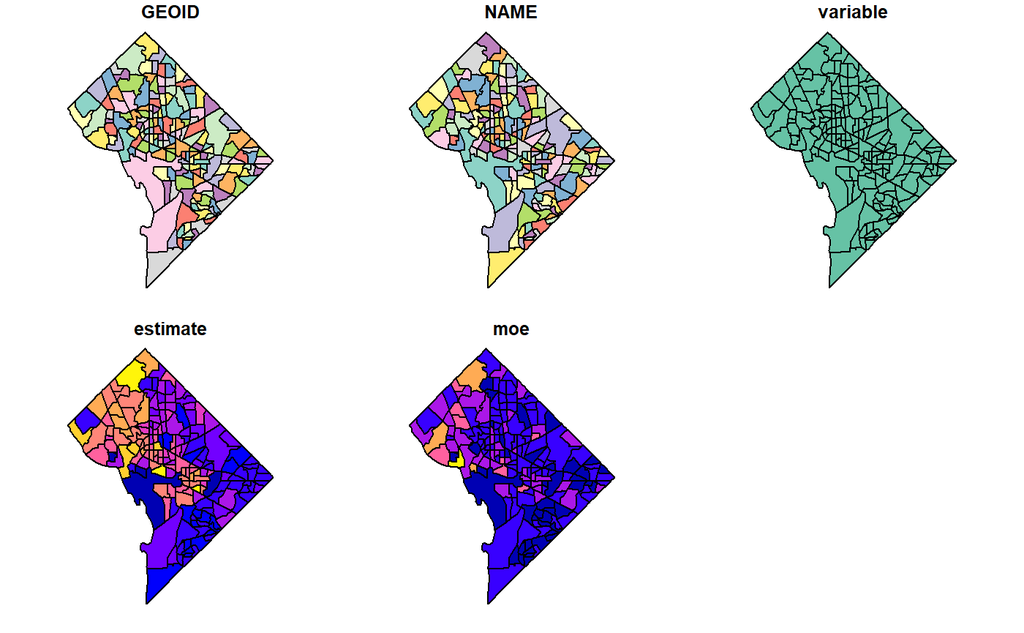

```r
plot(df_cencus)
```

It’s in long format. Let’s make it wide.

```r
df_cens=df_cencus %>% select(-moe) %>% spread(variable,estimate)

tm_shape(df_cens) +tm_polygons("median_inc",alpha=.5)
```

[interactive chart not shown]

```r
  tm_shape(neigh2) +tm_borders(col="blue",lwd=5,alpha=.2)+
  tm_shape(df_cens) +tm_borders(col="red",lwd=1,alpha=.3)
```

[interactive chart not shown]

```r
#<<<<<<< HEAD
#df_j=st_join(df_cens,neigh2)
#=======
#df_j=st_join(df_cens,neigh2,prepared=FALSE)
#>>>>>>> aaf01be5cf721819dd2df615aef7a1999bcec0c2
```

```r
df_cens_adj=df_cens %>% st_transform(4326)
```

```r
df_j=st_join(df_cens_adj,neigh2,largest=TRUE)
```

Other order?:

```r
#<<<<<<< HEAD
##df_j_rev = st_join(neigh2,df_cens_adj,largest=TRUE)
#=======
#df_j_rev = st_join(neigh2,df_cens_adj,largest=TRUE)
#>>>>>>> aaf01be5cf721819dd2df615aef7a1999bcec0c2
```

Since we want the geometry for the NEIGHBORHOODS, we need a to work a little harder:

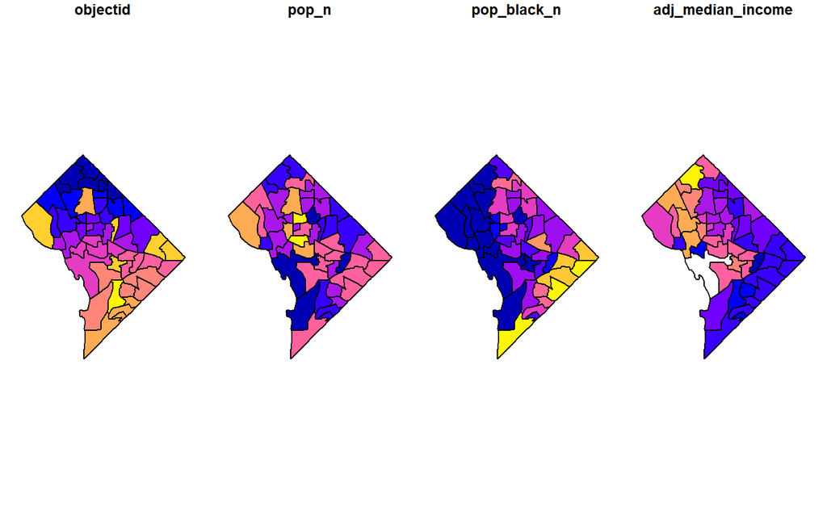

```r
df1=df_j %>% select(median_inc,pop,pop_black,objectid) %>%
  group_by(objectid) %>%
  summarise(pop_n=sum(pop),
            pop_black_n=sum(pop_black),
            adj_median_income=sum(pop*median_inc)/pop_n)

plot(df1)
```

```r
df2=left_join(neigh2,df1)
```

```
Error: y should not have class sf; for spatial joins, use st_join
```